# Market Segmentation

First, load the data.

```r
df = read.csv("social_marketing.csv")
```

View a sample of the data:

|  | X | chatter | current_events | travel | photo_sharing | uncategorized | tv_film | sports_fandom | politics | food | family | home_and_garden | music | news | online_gaming | shopping | health_nutrition | college_uni | sports_playing | cooking | eco | computers | business | outdoors | crafts | automotive | art | religion | beauty | … |
| --- | --- | --- | --- | --- | --- | --- | --- | --- | --- | --- | --- | --- | --- | --- | --- | --- | --- | --- | --- | --- | --- | --- | --- | --- | --- | --- | --- | --- | --- | --- |
| 1 | hmjoe4g3k | 2 | 0 | 2 | 2 | 2 | 1 | 1 | 0 | 4 | 1 | 2 | 0 | 0 | 0 | 1 | 17 | 0 | 2 | 5 | 1 | 1 | 0 | 2 | 1 | 0 | 0 | 1 | 0 | … |
| 2 | clk1m5w8s | 3 | 3 | 2 | 1 | 1 | 1 | 4 | 1 | 2 | 2 | 1 | 0 | 0 | 0 | 0 | 0 | 0 | 1 | 0 | 0 | 0 | 1 | 0 | 2 | 0 | 0 | 0 | 0 | … |
| 3 | jcsovtak3 | 6 | 3 | 4 | 3 | 1 | 5 | 0 | 2 | 1 | 1 | 1 | 1 | 1 | 0 | 2 | 0 | 0 | 0 | 2 | 1 | 0 | 0 | 0 | 2 | 0 | 8 | 0 | 1 | … |
| 4 | 3oeb4hiln | 1 | 5 | 2 | 2 | 0 | 1 | 0 | 1 | 0 | 1 | 0 | 0 | 0 | 0 | 0 | 0 | 1 | 0 | 0 | 0 | 0 | 1 | 0 | 3 | 0 | 2 | 0 | 1 | … |
| 5 | fd75x1vgk | 5 | 2 | 0 | 6 | 1 | 0 | 0 | 2 | 0 | 1 | 0 | 0 | 0 | 3 | 2 | 0 | 4 | 0 | 1 | 0 | 1 | 0 | 1 | 0 | 0 | 0 | 0 | 0 | … |
| 6 | h6nvj91yp | 6 | 4 | 2 | 7 | 0 | 1 | 1 | 0 | 2 | 1 | 1 | 1 | 0 | 0 | 5 | 0 | 0 | 0 | 0 | 0 | 1 | 1 | 0 | 0 | 1 | 0 | 0 | 0 | … |

Goal of Data Analysis: Find categories preferred by users so that NutrientH20 can tailor an appropriate marketing message.

Solution: Find the percentage of tweets per category, scale and find the most prominent clusters.

First, change the data frame total tweet numbers to fractions.

|  | chatter | current_events | travel | photo_sharing | uncategorized | tv_film | sports_fandom | politics | food | family | home_and_garden | music | news | online_gaming | shopping | health_nutrition | college_uni | sports_playing | cooking | eco | computers | business | outdoors | crafts | automotive | art | religion | beauty | parenting | … |
| --- | --- | --- | --- | --- | --- | --- | --- | --- | --- | --- | --- | --- | --- | --- | --- | --- | --- | --- | --- | --- | --- | --- | --- | --- | --- | --- | --- | --- | --- | --- |
| 1 | 0.03278689 | 0.00000000 | 0.03278689 | 0.03278689 | 0.03278689 | 0.01639344 | 0.01639344 | 0.00000000 | 0.06557377 | 0.01639344 | 0.03278689 | 0.00000000 | 0.0000000 | 0.0 | 0.01639344 | 0.2786885 | 0.00000000 | 0.03278689 | 0.08196721 | 0.01639344 | 0.01639344 | 0.00000000 | 0.03278689 | 0.01639344 | 0.00000000 | 0.0000000 | 0.01639344 | 0.00000000 | 0.01639344 | … |
| 2 | 0.10000000 | 0.10000000 | 0.06666667 | 0.03333333 | 0.03333333 | 0.03333333 | 0.13333333 | 0.03333333 | 0.06666667 | 0.06666667 | 0.03333333 | 0.00000000 | 0.0000000 | 0.0 | 0.00000000 | 0.0000000 | 0.00000000 | 0.03333333 | 0.00000000 | 0.00000000 | 0.00000000 | 0.03333333 | 0.00000000 | 0.06666667 | 0.00000000 | 0.0000000 | 0.00000000 | 0.00000000 | 0.00000000 | … |
| 3 | 0.12765957 | 0.06382979 | 0.08510638 | 0.06382979 | 0.02127660 | 0.10638298 | 0.00000000 | 0.04255319 | 0.02127660 | 0.02127660 | 0.02127660 | 0.02127660 | 0.0212766 | 0.0 | 0.04255319 | 0.0000000 | 0.00000000 | 0.00000000 | 0.04255319 | 0.02127660 | 0.00000000 | 0.00000000 | 0.00000000 | 0.04255319 | 0.00000000 | 0.1702128 | 0.00000000 | 0.02127660 | 0.00000000 | … |
| 4 | 0.04761905 | 0.23809524 | 0.09523810 | 0.09523810 | 0.00000000 | 0.04761905 | 0.00000000 | 0.04761905 | 0.00000000 | 0.04761905 | 0.00000000 | 0.00000000 | 0.0000000 | 0.0 | 0.00000000 | 0.0000000 | 0.04761905 | 0.00000000 | 0.00000000 | 0.00000000 | 0.00000000 | 0.04761905 | 0.00000000 | 0.14285714 | 0.00000000 | 0.0952381 | 0.00000000 | 0.04761905 | 0.00000000 | … |
| 5 | 0.16666667 | 0.06666667 | 0.00000000 | 0.20000000 | 0.03333333 | 0.00000000 | 0.00000000 | 0.06666667 | 0.00000000 | 0.03333333 | 0.00000000 | 0.00000000 | 0.0000000 | 0.1 | 0.06666667 | 0.0000000 | 0.13333333 | 0.00000000 | 0.03333333 | 0.00000000 | 0.03333333 | 0.00000000 | 0.03333333 | 0.00000000 | 0.00000000 | 0.0000000 | 0.00000000 | 0.00000000 | 0.00000000 | … |
| 6 | 0.17647059 | 0.11764706 | 0.05882353 | 0.20588235 | 0.00000000 | 0.02941176 | 0.02941176 | 0.00000000 | 0.05882353 | 0.02941176 | 0.02941176 | 0.02941176 | 0.0000000 | 0.0 | 0.14705882 | 0.0000000 | 0.00000000 | 0.00000000 | 0.00000000 | 0.00000000 | 0.02941176 | 0.02941176 | 0.00000000 | 0.00000000 | 0.02941176 | 0.0000000 | 0.00000000 | 0.00000000 | 0.00000000 | … |

```r
#set up parralel computing
library(foreach)
library(doParallel)
library(LICORS)
registerDoParallel(cores = 4)
```

```r
##register parralel backend
clusterTweeters = function(numK,df){
  model = LICORS::kmeanspp(df, k = numK,nstart = 10)
  #find ch value for the model
  clusterCrit::intCriteria(as.matrix(df),model$cluster,"Calinski_Harabasz")
}
tempDf = df
#drop chatter
tempDf$chatter= NULL
withoutChatter = foreach(k = 2:10,.combine = 'c')%dopar%
{
  clusterTweeters(k,tempDf)

}
```

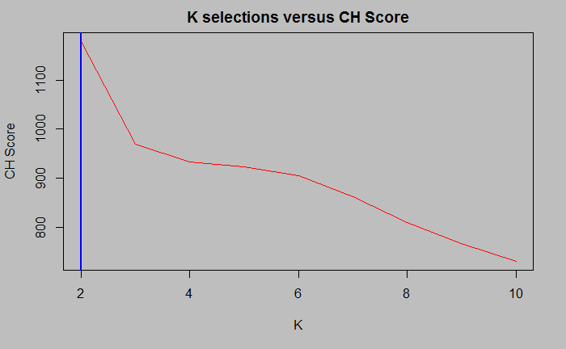

```r
par(bg = "gray")
plot(2:10,withoutChatter,main = "K selections versus CH Score",xlab = "K",ylab = "CH Score",type = "l",col = "red")
abline(v = (which.max(withoutChatter)+1),col = "blue",lw = 2)
```

After dropping chatter from the data set (because of it’s inability to direct NutrientH20’s marketing message), K-means was conducted to determine market segmentation. We optimized for the number of segments that resulted in the best CH score. K = 2 for that segmentation. See chart above.

Next, let’s analyze the important components of that each cluster. In other words, for each cluster’s centriod, let’s look for the centriod with the highest value.

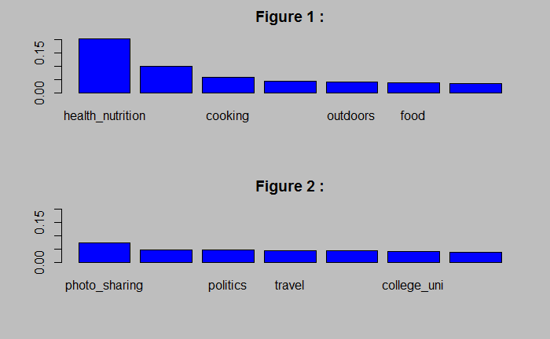

```r
optimalModel = LICORS::kmeanspp(tempDf, (which.max(withoutChatter)+1),nstart = 10)
#plot parameters for each model
topN = 7
centriodMat = matrix(NA,2,topN)
par(bg = "gray",mfrow = c(2,1))
for (k in 1:2)
{
  sorted = sort(optimalModel$centers[k,],decreasing = TRUE)[1:topN]
  barplot(sorted,ylim = c(0,.23),col = "blue",main = paste("Figure",k,":"))
  centriodMat[k,] = names(sorted)
}
```

```r
print(paste("Top Most important centriod indicators per cluster: "))
```

```
[1] "Top Most important centriod indicators per cluster: "
```

```r
centriodMat
```

```
     [,1]               [,2]               [,3]       [,4]            [,5]            [,6]          [,7]
[1,] "health_nutrition" "personal_fitness" "cooking"  "photo_sharing" "outdoors"      "food"        "current_events"
[2,] "photo_sharing"    "current_events"   "politics" "travel"        "sports_fandom" "college_uni" "cooking"
```

The one of the clusters looks to be composed of people who are very concious of their health. They seem to be focused on Personal Fitness and are interested in the outdoors. This indicates a very physically active group of people and would recommend that the marketing message ought to be related to personal health. This cluster contains this fraction of social media users:

```r
length(which(optimalModel$cluster == 1))/length(optimalModel$cluster)
```

```
[1] 0.2048972
```

The second cluster appears to be grouped for millenials. Politically engage(current__events and politics), educated (college_uni) and active in photo sharing, this could be a young group of people. We would need to dig more into the profiles of this segment, but a marketing strategy focused on millenials could be appropriate.